# Homicide Reports (Part Three)

Lauren Hartman

4/30/2017

# The Scenario

My main goal is determining patterns in relation to the weapon used in a murder. 14,330 observations are present for 2014. I would also like to know which model is the most accurate in determining which weapon was used in a murder.

# Naive Bayes Model -Pulling the Data In

Dataset is from Kaggle. Due to time contraint and processing limitations, will only be looking at homicides which occured in 2014. 2014 is the most current year available in this dataset.

```r
Report <- read.csv("/Users/laurenhartman/Documents/HomicideReports.csv", header = TRUE)

newReport <- Report[624125:638455, ]

options(scipen=999)

summary(newReport)
```

```
##    Record.ID       Agency.Code          Agency.Name
##  Min.   :624125   ILCPD00:  438   Chicago     :  438
##  1st Qu.:627707   NY03030:  345   New York    :  345
##  Median :631290   MI82349:  315   Detroit     :  315
##  Mean   :631290   CA01942:  280   Los Angeles :  280
##  3rd Qu.:634872   PAPEP00:  258   Philadelphia:  264
##  Max.   :638454   (Other):12694   (Other)     :12688
##  NA's   :1        NA's   :    1   NA's        :    1
##            Agency.Type             City                State
##  Municipal Police:10942   Los Angeles:  572   California  :1872
##  Sheriff         : 2533   Cook       :  439   Texas       :1324
##  County Police   :  475   Wayne      :  376   Florida     :1156
##  State Police    :  346   Harris     :  359   Pennsylvania: 646
##  Special Police  :   28   New York   :  345   New York    : 642
##  (Other)         :    6   (Other)    :12239   (Other)     :8690
##  NA's            :    1   NA's       :    1   NA's        :   1
##       Year           Month         Incident
##  Min.   :2014   December:1309   Min.   :  0.00
##  1st Qu.:2014   May     :1300   1st Qu.:  1.00
##  Median :2014   August  :1292   Median :  2.00
##  Mean   :2014   October :1265   Mean   : 41.28
##  3rd Qu.:2014   July    :1258   3rd Qu.:  8.00
##  Max.   :2014   (Other) :7906   Max.   :999.00
##  NA's   :1      NA's    :   1   NA's   :1
##                       Crime.Type    Crime.Solved   Victim.Sex
##  Manslaughter by Negligence:  317   No  :4380    Female : 3107
##  Murder or Manslaughter    :14013   Yes :9950    Male   :11187
##  NA's                      :    1   NA's:   1    Unknown:   36
##                                                  NA's   :    1
##
##
##
##    Victim.Age                            Victim.Race
##  Min.   :  0.00   Asian/Pacific Islander       : 233
##  1st Qu.: 22.00   Black                        :7110
##  Median : 31.00   Native American/Alaska Native: 112
##  Mean   : 41.01   Unknown                      : 174
##  3rd Qu.: 44.00   White                        :6701
##  Max.   :998.00   NA's                         :   1
##  NA's   :1
```

[output cut: 17 more lines]

```
##  Unknown     :7413   Handgun     :6594   Min.   :0.000   Min.   : 0.0000
##  Stranger    :1961   Firearm     :2525   1st Qu.:0.000   1st Qu.: 0.0000
##  Acquaintance:1821   Knife       :1747   Median :0.000   Median : 0.0000
##  Wife        : 502   Blunt Object:1291   Mean   :0.144   Mean   : 0.2432
##  Girlfriend  : 430   Unknown     :1005   3rd Qu.:0.000   3rd Qu.: 0.0000
##  (Other)     :2203   (Other)     :1168   Max.   :9.000   Max.   :10.0000
##  NA's        :   1   NA's        :   1   NA's   :1       NA's   :1
##  Record.Source
##  FBI :13174
##  FOIA: 1156
##  NA's:    1
##
##
##
##
```

I do not believe the Record.ID, Agency.Code, and Agency.Name would add any benefit to my analysis. ID columns should always be taken out since they are random. I am not willing to do substituion or imputation on the City column due to time constraint. The state column will provide enough geographical information for my analysis. All observations are from 2014, so no need to keep the Year column. I am not interested in the relation between weapon choice and incident. I may use incorporate this column in the future, however. The Victim.Ethnicity and the Perpetrator.Ethnicity columns have a large number of unknown values, which would add very little insight for the analysis. The unknown values appear to be largely influenced by whether a crime was solved or not solved. Not interested in the number of victims involved in the homicide or the number of perpetrators present during the homicide. Could easily incorporate into a future analysis. I am also not interested in which organization provided a particular homicide record.

```r
newReport <- newReport[-1]
newReport <- newReport[-23]
newReport <- newReport[-22]
newReport <- newReport[-21]
newReport <- newReport[-1]
newReport <- newReport[-1]
newReport <- newReport[-1]
newReport <- newReport[-3]
newReport <- newReport[-4]
newReport <- newReport[-9]
newReport <- newReport[-12]
newReport <- newReport[-1]

summary(newReport)
```

```
##           State           Month                           Crime.Type
##  California  :1872   December:1309   Manslaughter by Negligence:  317
##  Texas       :1324   May     :1300   Murder or Manslaughter    :14013
##  Florida     :1156   August  :1292   NA's                      :    1
##  Pennsylvania: 646   October :1265
##  New York    : 642   July    :1258
##  (Other)     :8690   (Other) :7906
##  NA's        :   1   NA's    :   1
##  Crime.Solved   Victim.Sex      Victim.Age
##  No  :4380    Female : 3107   Min.   :  0.00
##  Yes :9950    Male   :11187   1st Qu.: 22.00
##  NA's:   1    Unknown:   36   Median : 31.00
##               NA's   :    1   Mean   : 41.01
##                               3rd Qu.: 44.00
##                               Max.   :998.00
##                               NA's   :1
##                         Victim.Race   Perpetrator.Sex Perpetrator.Age
##  Asian/Pacific Islander       : 233   Female : 989    Min.   : 0.00
##  Black                        :7110   Male   :8942    1st Qu.: 0.00
##  Native American/Alaska Native: 112   Unknown:4399    Median :22.00
##  Unknown                      : 174   NA's   :   1    Mean   :21.79
##  White                        :6701                   3rd Qu.:34.00
##  NA's                         :   1                   Max.   :99.00
##                                                       NA's   :2
##                       Perpetrator.Race       Relationship
##  Asian/Pacific Islander       : 144    Unknown     :7413
##  Black                        :4583    Stranger    :1961
##  Native American/Alaska Native:  91    Acquaintance:1821
##  Unknown                      :4558    Wife        : 502
##  White                        :4954    Girlfriend  : 430
##  NA's                         :   1    (Other)     :2203
##                                        NA's        :   1
##           Weapon
##  Handgun     :6594
##  Firearm     :2525
##  Knife       :1747
##  Blunt Object:1291
##  Unknown     :1005
##  (Other)     :1168
##  NA's        :   1
```

```r
newReport$Weapon[is.na(newReport$Weapon)] <- "Handgun"
newReport$State[is.na(newReport$State)] <- "California"
newReport$Month[is.na(newReport$Month)] <- "December"
newReport$Crime.Type[is.na(newReport$Crime.Type)] <- "Murder or Manslaughter"
newReport$Crime.Solved[is.na(newReport$Crime.Solved)] <- "Yes"
newReport$Victim.Sex[is.na(newReport$Victim.Sex)] <- "Male"
newReport$Victim.Age[is.na(newReport$Victim.Age)] <- 30
newReport$Victim.Race[is.na(newReport$Victim.Race)] <- "Black"
newReport$Perpetrator.Sex[is.na(newReport$Perpetrator.Sex)] <- "Male"
newReport$Perpetrator.Age[is.na(newReport$Perpetrator.Age)] <- 29
newReport$Perpetrator.Race[is.na(newReport$Perpetrator.Race)] <- "White"
newReport$Relationship[is.na(newReport$Relationship)] <- "Stranger"

summary(newReport)
```

```
##           State           Month                           Crime.Type
##  California  :1873   December:1310   Manslaughter by Negligence:  317
##  Texas       :1324   May     :1300   Murder or Manslaughter    :14014
##  Florida     :1156   August  :1292
##  Pennsylvania: 646   October :1265
##  New York    : 642   July    :1258
##  Georgia     : 608   June    :1208
##  (Other)     :8082   (Other) :6698
##  Crime.Solved   Victim.Sex      Victim.Age
##  No :4380     Female : 3107   Min.   :  0.00
##  Yes:9951     Male   :11188   1st Qu.: 22.00
##               Unknown:   36   Median : 31.00
##                               Mean   : 41.01
##                               3rd Qu.: 44.00
##                               Max.   :998.00
##
##                         Victim.Race   Perpetrator.Sex Perpetrator.Age
##  Asian/Pacific Islander       : 233   Female : 989    Min.   : 0.00
##  Black                        :7111   Male   :8943    1st Qu.: 0.00
##  Native American/Alaska Native: 112   Unknown:4399    Median :22.00
##  Unknown                      : 174                   Mean   :21.79
##  White                        :6701                   3rd Qu.:34.00
##                                                       Max.   :99.00
##
##                       Perpetrator.Race       Relationship
##  Asian/Pacific Islander       : 144    Unknown     :7413
##  Black                        :4583    Stranger    :1962
##  Native American/Alaska Native:  91    Acquaintance:1821
##  Unknown                      :4558    Wife        : 502
##  White                        :4955    Girlfriend  : 430
##                                        Friend      : 382
##                                        (Other)     :1821
##           Weapon
##  Handgun     :6595
##  Firearm     :2525
##  Knife       :1747
##  Blunt Object:1291
##  Unknown     :1005
##  Rifle       : 350
##  (Other)     : 818
```

# Train and Test Sets for the Naive Bayes Model

Will have the train set contain 80% of the observations while the test set has 20% of the observations.

```r
newReport_train <- newReport[1:11464, ]
newReport_test <- newReport[11465:14330, ]
```

The line below specifies the variable of interest is the weapon used in a homicide.

```r
newReport_train_labels <- newReport[1:11464, ]$Weapon
newReport_test_labels <- newReport[11465:14330, ]$Weapon
```

```r
prop.table(table(newReport_train_labels))
```

```
## newReport_train_labels
##  Blunt Object      Drowning         Drugs    Explosives          Fall
##  0.0850488486  0.0014829030  0.0068039079  0.0005233775  0.0002616888
##          Fire       Firearm           Gun       Handgun         Knife
##  0.0059316120  0.1728018144  0.0075017446  0.4705163992  0.1242149337
##        Poison         Rifle       Shotgun Strangulation   Suffocation
##  0.0006978367  0.0225052338  0.0208478716  0.0069783671  0.0068911375
##       Unknown
##  0.0669923238
```

```r
prop.table(table(newReport_test_labels))
```

```
## newReport_test_labels
##  Blunt Object      Drowning         Drugs    Explosives          Fall
##  0.1102581996  0.0010467551  0.0059316120  0.0006978367  0.0000000000
##          Fire       Firearm           Gun       Handgun         Knife
##  0.0041870202  0.1898115841  0.0048848569  0.4187020237  0.1127006281
##        Poison         Rifle       Shotgun Strangulation   Suffocation
##  0.0006978367  0.0321004885  0.0230286113  0.0038381019  0.0094207955
##       Unknown
##  0.0826936497
```

The train and test sets have roughly the same distribution of cases where a specific weapon was used, give or take up to roughly 6.0%.

# Running the Model

I will use Naive Bayes since this model commonly performs well, especially when focusing primarily on accuracy. Naive Bayes assumes independence between the predictior variables. Using a Naive Bayes Model on the train set.

```r
library(e1071)

Weapon_Classifier <- naiveBayes(newReport_train, newReport_train_labels)
```

# Evaluating Model Performance

Seeing how well the Naive Bayes set performs on the test set give what the model learned from the train set.

```r
Weapon_Classifier_Pred <- predict(Weapon_Classifier, newReport_test)
```

```r
table <- table(newReport_test_labels, Weapon_Classifier_Pred)

print(table)
```

```
##                      Weapon_Classifier_Pred
## newReport_test_labels Blunt Object Drowning Drugs Explosives Fall Fire
##         Blunt Object           306        1     2          0    0    0
##         Drowning                 0        3     0          0    0    0
##         Drugs                    0        0    16          0    0    0
##         Explosives               0        0     0          0    0    0
##         Fall                     0        0     0          0    0    0
##         Fire                     0        0     1          0    0    9
##         Firearm                  0        0     1          1    0    0
##         Gun                      0        0     0          0    0    0
##         Handgun                  0        0     1          2    0    0
##         Knife                    0        0     0          0    0    0
##         Poison                   0        0     0          0    0    0
##         Rifle                    0        0     1          0    0    0
##         Shotgun                  0        0     0          0    0    0
##         Strangulation            0        0     0          0    0    0
##         Suffocation              1        0     0          0    0    0
##         Unknown                  0        0     3          1    0    0
##                      Weapon_Classifier_Pred
## newReport_test_labels Firearm  Gun Handgun Knife Poison Rifle Shotgun
##         Blunt Object        0    0       6     0      0     0       0
##         Drowning            0    0       0     0      0     0       0
##         Drugs               0    0       1     0      0     0       0
##         Explosives          0    0       0     2      0     0       0
##         Fall                0    0       0     0      0     0       0
##         Fire                0    0       1     1      0     0       0
##         Firearm           537    0       0     3      0     0       1
##         Gun                 0   10       2     1      0     0       0
##         Handgun             0    0    1194     0      0     0       0
##         Knife               0    0       0   321      0     0       0
##         Poison              0    0       0     0      1     0       1
##         Rifle               0    0       0     0      0    90       0
##         Shotgun             1    0       5     0      0     0      60
##         Strangulation       0    0       2     0      0     0       0
##         Suffocation         1    0       2     0      0     0       0
##         Unknown             0    0       0     0      0     0       0
##                      Weapon_Classifier_Pred
## newReport_test_labels Strangulation Suffocation Unknown
##         Blunt Object              1           0       0
##         Drowning                  0           0       0
##         Drugs                     0           0       0
##         Explosives                0           0       0
##         Fall                      0           0       0
##         Fire                      0           0       0
##         Firearm                   1           0       0
##         Gun                       1           0       0
##         Handgun                   3           0       0
##         Knife                     2           0       0
##         Poison                    0           0       0
##         Rifle                     1           0       0
##         Shotgun                   0           0       0
##         Strangulation             9           0       0
##         Suffocation               0          23       0
##         Unknown                   2           0     231
```

Accuracy = 98%. Wow. 2866 total observations. The Naive Bayes Model correctly guessed the weapon used in 2810 observations. This high of accuracy rating does make me skeptical, however. Falls under “too good to be true.”

# Dealing With Odd Age Range

Assume minimum age is 0 and maximum age is 99 for the victim. I will assume minimum age for a perpetrator is three and the maximum age is 80. I do not want outliers influencing the results of the predictions. I have a hard time believing a victim happened to be 998 years old. Also hard to believe a perpetrator is less than 3 years old or older than 80 due to normal physical capabilities below three years old and above eighty years old.

```r
newReport$Victim.Age <- ifelse(newReport$Victim.Age >= 0 & newReport$Victim.Age <= 99,
                     newReport$Victim.Age, NA)

newReport$Perpetrator.Age <- ifelse(newReport$Perpetrator.Age >= 3 & newReport$Perpetrator.Age <= 80,
                     newReport$Perpetrator.Age, NA)
```

# Dealing With Missing Data for the Victim.Age Column

I already replaced the missing values for age earlier on. This is how I determined the median age used to replace the NA values in the age columns.

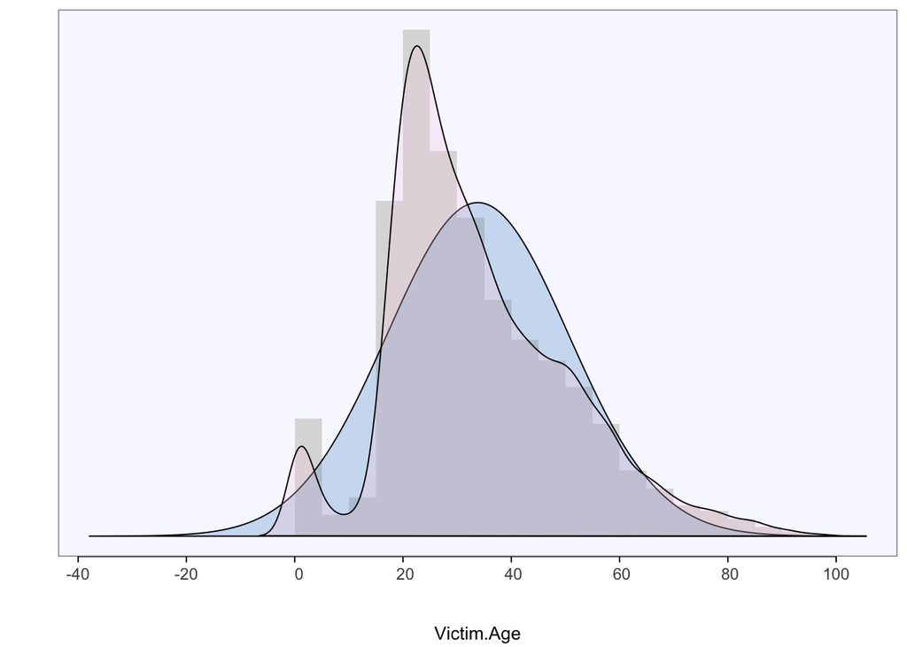

```
##
##
## Sample Size:  14224
## Missing Values:  107
##
## Density bandwidth for general curve: 2.1825
## For a smoother curve, increase bandwidth with option: bw
##
## Sample size out of range for Shapiro-Wilk normality test.
##
##
## (Box plot) Outliers: 236
## Small:  none
## Large: 78 78 78 78 78 78 78 78 78 78 78 78 78 78 78 78 ...  97 97 97 97 99 99
```

```r
library(lessR)
Density(Victim.Age, data=newReport)
```

The distribution is not normal. I will use median imputation.

```r
median_age <- median(newReport$Victim.Age, na.rm = TRUE)

newReport$Victim.Age <- ifelse(is.na(newReport$Victim.Age), median_age, newReport$Victim.Age)

summary(newReport$Victim.Age)
```

```
##    Min. 1st Qu.  Median    Mean 3rd Qu.    Max.
##    0.00   22.00   30.00   33.79   44.00   99.00
```

Based on my assumption, the median victim age is 30 years old.

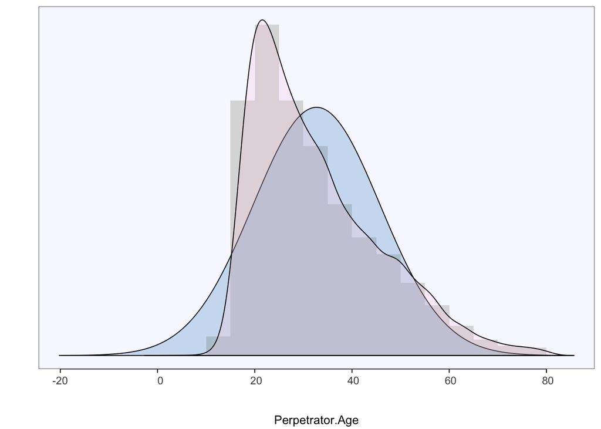

```
##
##
## Sample Size:  9417
## Missing Values:  4914
##
## Density bandwidth for general curve: 1.8866
## For a smoother curve, increase bandwidth with option: bw
##
## Sample size out of range for Shapiro-Wilk normality test.
##
##
## (Box plot) Outliers: 152
## Small:  none
## Large: 68 68 68 68 68 68 68 68 68 68 68 68 68 68 68 68 ...  80 80 80 80 80 80
```

```r
Density(Perpetrator.Age, data=newReport)
```

```r
median_age2 <- median(newReport$Perpetrator.Age, na.rm = TRUE)

newReport$Perpetrator.Age <- ifelse(is.na(newReport$Perpetrator.Age), median_age2, newReport$Perpetrator.Age)

summary(newReport$Perpetrator.Age)
```

```
##    Min. 1st Qu.  Median    Mean 3rd Qu.    Max.
##    3.00   26.00   29.00   31.44   34.00   80.00
```

Based on my assumption, the median perpetrator age is 29 years old.

In preparation for the next model, I will ensure all predictors are factors. The age columns are not, so will covert into factors.

```r
newReport$Victim.Age <- as.factor(newReport$Victim.Age)

table(newReport$Victim.Age)
```

```
##
##   0   1   2   3   4   5   6   7   8   9  10  11  12  13  14  15  16  17
## 200 154 104  72  40  29  28  22  17  17  25  17  17  27  47  89 161 255
##  18  19  20  21  22  23  24  25  26  27  28  29  30  31  32  33  34  35
## 345 451 494 511 550 531 501 484 439 389 388 389 463 326 358 319 321 296
##  36  37  38  39  40  41  42  43  44  45  46  47  48  49  50  51  52  53
## 265 261 252 213 213 218 200 205 185 193 182 175 166 176 196 181 154 163
##  54  55  56  57  58  59  60  61  62  63  64  65  66  67  68  69  70  71
## 133 130 119 136 109 115  91  76  70  64  53  73  59  55  49  38  40  40
##  72  73  74  75  76  77  78  79  80  81  82  83  84  85  86  87  88  89
##  29  33  24  30  30  25  29  24  21  13  19  15  18  21  13  10   8   7
##  90  91  92  93  94  96  97  99
##   7   9   5   5   2   4   4   2
```

```r
newReport$Perpetrator.Age <- as.factor(newReport$Perpetrator.Age)

table(newReport$Perpetrator.Age)
```

```
##
##    3    6    9   10   11   12   13   14   15   16   17   18   19   20   21
##    1    1    1    1    4    6    9   22   70  144  225  320  393  395  422
##   22   23   24   25   26   27   28   29   30   31   32   33   34   35   36
##  400  387  365  342  334  284  310 5189  274  240  264  228  245  235  201
##   37   38   39   40   41   42   43   44   45   46   47   48   49   50   51
##  165  174  166  169  137  140  142  153  113  117  110  111  120  129   89
##   52   53   54   55   56   57   58   59   60   61   62   63   64   65   66
##   90   93   72   77   84   70   52   55   29   45   31   46   24   25   22
##   67   68   69   70   71   72   73   74   75   76   77   78   79   80
##   17   21   19   12   13   11   14    8    9   12    9    9    3   12
```

Now all predictors are factors. Now only one more step before I run the data through an association model.

```r
str(newReport)
```

```
## 'data.frame':    14331 obs. of  12 variables:
##  $ State           : Factor w/ 51 levels "Alabama","Alaska",..: 2 2 2 2 2 2 2 2 2 2 ...
##  $ Month           : Factor w/ 12 levels "April","August",..: 5 5 4 8 1 1 7 2 2 12 ...
##  $ Crime.Type      : Factor w/ 2 levels "Manslaughter by Negligence",..: 2 1 2 2 2 1 2 2 2 2 ...
##  $ Crime.Solved    : Factor w/ 2 levels "No","Yes": 1 2 2 1 2 2 2 2 2 2 ...
##  $ Victim.Sex      : Factor w/ 3 levels "Female","Male",..: 2 2 2 2 1 2 1 2 2 2 ...
##  $ Victim.Age      : Factor w/ 98 levels "0","1","2","3",..: 32 56 23 56 16 37 21 52 64 24 ...
##  $ Victim.Race     : Factor w/ 5 levels "Asian/Pacific Islander",..: 5 5 2 3 2 2 5 5 1 5 ...
##  $ Perpetrator.Sex : Factor w/ 3 levels "Female","Male",..: 3 1 2 3 2 2 2 2 2 2 ...
##  $ Perpetrator.Age : Factor w/ 74 levels "3","6","9","10",..: 23 58 13 23 18 33 16 32 45 20 ...
##  $ Perpetrator.Race: Factor w/ 5 levels "Asian/Pacific Islander",..: 4 5 5 4 2 3 5 3 5 2 ...
##  $ Relationship    : Factor w/ 28 levels "Acquaintance",..: 27 27 19 27 1 26 15 12 27 1 ...
##  $ Weapon          : Factor w/ 16 levels "Blunt Object",..: 7 6 7 7 7 1 7 10 8 7 ...
```

```r
summary(newReport)
```

```
##           State           Month                           Crime.Type
##  California  :1873   December:1310   Manslaughter by Negligence:  317
##  Texas       :1324   May     :1300   Murder or Manslaughter    :14014
##  Florida     :1156   August  :1292
##  Pennsylvania: 646   October :1265
##  New York    : 642   July    :1258
##  Georgia     : 608   June    :1208
##  (Other)     :8082   (Other) :6698
##  Crime.Solved   Victim.Sex      Victim.Age
##  No :4380     Female : 3107   22     :  550
##  Yes:9951     Male   :11188   23     :  531
##               Unknown:   36   21     :  511
##                               24     :  501
##                               20     :  494
##                               25     :  484
##                               (Other):11260
##                         Victim.Race   Perpetrator.Sex Perpetrator.Age
##  Asian/Pacific Islander       : 233   Female : 989    29     :5189
##  Black                        :7111   Male   :8943    21     : 422
##  Native American/Alaska Native: 112   Unknown:4399    22     : 400
##  Unknown                      : 174                   20     : 395
##  White                        :6701                   19     : 393
##                                                       23     : 387
##                                                       (Other):7145
##                       Perpetrator.Race       Relationship
##  Asian/Pacific Islander       : 144    Unknown     :7413
##  Black                        :4583    Stranger    :1962
##  Native American/Alaska Native:  91    Acquaintance:1821
##  Unknown                      :4558    Wife        : 502
##  White                        :4955    Girlfriend  : 430
##                                        Friend      : 382
##                                        (Other)     :1821
##           Weapon
##  Handgun     :6595
##  Firearm     :2525
##  Knife       :1747
##  Blunt Object:1291
##  Unknown     :1005
##  Rifle       : 350
##  (Other)     : 818
```

```r
newReport <- newReport[-3]
newReport <- newReport[-3]
newReport <- newReport[-6]
newReport <- newReport[-7]
newReport <- newReport[-7]

summary(newReport)
```

```
##           State           Month        Victim.Sex      Victim.Age
##  California  :1873   December:1310   Female : 3107   22     :  550
##  Texas       :1324   May     :1300   Male   :11188   23     :  531
##  Florida     :1156   August  :1292   Unknown:   36   21     :  511
##  Pennsylvania: 646   October :1265                   24     :  501
##  New York    : 642   July    :1258                   20     :  494
##  Georgia     : 608   June    :1208                   25     :  484
##  (Other)     :8082   (Other) :6698                   (Other):11260
##                         Victim.Race   Perpetrator.Age          Weapon
##  Asian/Pacific Islander       : 233   29     :5189    Handgun     :6595
##  Black                        :7111   21     : 422    Firearm     :2525
##  Native American/Alaska Native: 112   22     : 400    Knife       :1747
##  Unknown                      : 174   20     : 395    Blunt Object:1291
##  White                        :6701   19     : 393    Unknown     :1005
##                                       23     : 387    Rifle       : 350
##                                       (Other):7145    (Other)     : 818
```

# Association - Market Basket Analysis

The apriori model generates “rules” which provide insight into relations between the variables. Support = .1 and confidence = .8. Support refers to the percent of observations a characteristic appears in. In this case, a characteristic must appear in at least 10% of the observations. Using a confidence interval of 80% is saying that the results of this sample, if repeated over and over, would match the results found in the actual population 80% of the time.

```r
library(arules)
newReport_Rules <- apriori(newReport)
```

```
## Apriori
##
## Parameter specification:
##  confidence minval smax arem  aval originalSupport maxtime support minlen
##         0.8    0.1    1 none FALSE            TRUE       5     0.1      1
##  maxlen target   ext
##      10  rules FALSE
##
## Algorithmic control:
##  filter tree heap memopt load sort verbose
##     0.1 TRUE TRUE  FALSE TRUE    2    TRUE
##
## Absolute minimum support count: 1433
##
## set item appearances ...[0 item(s)] done [0.00s].
## set transactions ...[259 item(s), 14331 transaction(s)] done [0.00s].
## sorting and recoding items ... [9 item(s)] done [0.00s].
## creating transaction tree ... done [0.00s].
## checking subsets of size 1 2 3 4 done [0.00s].
## writing ... [9 rule(s)] done [0.00s].
## creating S4 object  ... done [0.00s].
```

Using the above specifications will result in only 9 rules.

Now I will drop the confidence level but will increase support. I will also specify that a rule must have more than one relationship present.

```r
newReport_Rules<- apriori(newReport, parameter = list(support = .2, confidence = .25, minlen = 2))
```

```
## Apriori
##
## Parameter specification:
##  confidence minval smax arem  aval originalSupport maxtime support minlen
##        0.25    0.1    1 none FALSE            TRUE       5     0.2      2
##  maxlen target   ext
##      10  rules FALSE
##
## Algorithmic control:
##  filter tree heap memopt load sort verbose
##     0.1 TRUE TRUE  FALSE TRUE    2    TRUE
##
## Absolute minimum support count: 2866
##
## set item appearances ...[0 item(s)] done [0.00s].
## set transactions ...[259 item(s), 14331 transaction(s)] done [0.00s].
## sorting and recoding items ... [6 item(s)] done [0.00s].
## creating transaction tree ... done [0.00s].
## checking subsets of size 1 2 3 done [0.00s].
## writing ... [18 rule(s)] done [0.00s].
## creating S4 object  ... done [0.00s].
```

I still want more rules.

I will drop the support back to .1 and increase the confidence to .5. I also do not want more than ten relationships present in a rule.

```r
newReport_Rules <- apriori(newReport, parameter = list(support = .1, confidence = .50, minlen = 2, maxlen = 10))
```

```
## Apriori
##
## Parameter specification:
##  confidence minval smax arem  aval originalSupport maxtime support minlen
##         0.5    0.1    1 none FALSE            TRUE       5     0.1      2
##  maxlen target   ext
##      10  rules FALSE
##
## Algorithmic control:
##  filter tree heap memopt load sort verbose
##     0.1 TRUE TRUE  FALSE TRUE    2    TRUE
##
## Absolute minimum support count: 1433
##
## set item appearances ...[0 item(s)] done [0.00s].
## set transactions ...[259 item(s), 14331 transaction(s)] done [0.00s].
## sorting and recoding items ... [9 item(s)] done [0.00s].
## creating transaction tree ... done [0.00s].
## checking subsets of size 1 2 3 4 done [0.00s].
## writing ... [27 rule(s)] done [0.00s].
## creating S4 object  ... done [0.00s].
```

The specification above results in 27 rules.

Will look at the third model, which has 27 rules. The median support is approximately .2 and the median confidence is approximately .66.

```r
summary(newReport_Rules)
```

```
## set of 27 rules
##
## rule length distribution (lhs + rhs):sizes
##  2  3  4
## 12 11  4
##
##    Min. 1st Qu.  Median    Mean 3rd Qu.    Max.
##   2.000   2.000   3.000   2.704   3.000   4.000
##
## summary of quality measures:
##     support         confidence          lift
##  Min.   :0.1079   Min.   :0.5037   Min.   :0.9047
##  1st Qu.:0.1377   1st Qu.:0.5889   1st Qu.:1.1101
##  Median :0.1897   Median :0.6619   Median :1.1923
##  Mean   :0.2156   Mean   :0.7038   Mean   :1.2144
##  3rd Qu.:0.2613   3rd Qu.:0.8482   3rd Qu.:1.3217
##  Max.   :0.4268   Max.   :0.9308   Max.   :1.5011
##
## mining info:
##       data ntransactions support confidence
##  newReport         14331     0.1        0.5
```

```r
inspect(newReport_Rules)
```

```
##      lhs                     rhs                    support confidence      lift
## [1]  {State=California}   => {Victim.Sex=Male}    0.1078780  0.8254138 1.0572940
## [2]  {Weapon=Firearm}     => {Victim.Sex=Male}    0.1499546  0.8510891 1.0901822
## [3]  {Victim.Sex=Female}  => {Victim.Race=White}  0.1373247  0.6334084 1.3546301
## [4]  {Perpetrator.Age=29} => {Weapon=Handgun}     0.1897286  0.5239931 1.1386421
## [5]  {Perpetrator.Age=29} => {Victim.Race=Black}  0.2291536  0.6328772 1.2754555
## [6]  {Perpetrator.Age=29} => {Victim.Sex=Male}    0.3161677  0.8731933 1.1184960
## [7]  {Weapon=Handgun}     => {Victim.Race=Black}  0.2741609  0.5957544 1.2006407
## [8]  {Victim.Race=Black}  => {Weapon=Handgun}     0.2741609  0.5525243 1.2006407
## [9]  {Weapon=Handgun}     => {Victim.Sex=Male}    0.3890168  0.8453374 1.0828146
## [10] {Victim.Race=White}  => {Victim.Sex=Male}    0.3302631  0.7063125 0.9047340
## [11] {Victim.Race=Black}  => {Victim.Sex=Male}    0.4267671  0.8600759 1.1016936
## [12] {Victim.Sex=Male}    => {Victim.Race=Black}  0.4267671  0.5466571 1.1016936
## [13] {Perpetrator.Age=29,
##       Weapon=Handgun}     => {Victim.Race=Black}  0.1380922  0.7278411 1.4668389
## [14] {Victim.Race=Black,
##       Perpetrator.Age=29} => {Weapon=Handgun}     0.1380922  0.6026188 1.3094965
## [15] {Victim.Race=Black,
##       Weapon=Handgun}     => {Perpetrator.Age=29} 0.1380922  0.5036905 1.3910944
## [16] {Perpetrator.Age=29,
##       Weapon=Handgun}     => {Victim.Sex=Male}    0.1725630  0.9095256 1.1650349
## [17] {Victim.Sex=Male,
##       Perpetrator.Age=29} => {Weapon=Handgun}     0.1725630  0.5457956 1.1860193
## [18] {Victim.Race=Black,
##       Perpetrator.Age=29} => {Victim.Sex=Male}    0.2092666  0.9132156 1.1697616
## [19] {Victim.Sex=Male,
##       Perpetrator.Age=29} => {Victim.Race=Black}  0.2092666  0.6618848 1.3339152
## [20] {Victim.Race=White,
##       Weapon=Handgun}     => {Victim.Sex=Male}    0.1324402  0.7564767 0.9689906
## [21] {Victim.Race=Black,
##       Weapon=Handgun}     => {Victim.Sex=Male}    0.2484125  0.9060830 1.1606252
## [22] {Victim.Sex=Male,
##       Weapon=Handgun}     => {Victim.Race=Black}  0.2484125  0.6385650 1.2869182
## [23] {Victim.Sex=Male,
##       Victim.Race=Black}  => {Weapon=Handgun}     0.2484125  0.5820798 1.2648651
## [24] {Victim.Race=Black,
##       Perpetrator.Age=29,
##       Weapon=Handgun}     => {Victim.Sex=Male}    0.1285326  0.9307731 1.1922515
## [25] {Victim.Sex=Male,
##       Perpetrator.Age=29,
##       Weapon=Handgun}     => {Victim.Race=Black}  0.1285326  0.7448443 1.5011059
## [26] {Victim.Sex=Male,
##       Victim.Race=Black,
##       Perpetrator.Age=29} => {Weapon=Handgun}     0.1285326  0.6142047 1.3346729
## [27] {Victim.Sex=Male,
##       Victim.Race=Black,
##       Weapon=Handgun}     => {Perpetrator.Age=29} 0.1285326  0.5174157 1.4290007
```

The following definitions were found on Quora: A firearm is a subclass of a gun which has a bullet propelled by an explosive charge such as gunpowder. Firearms are always easy to carry around. Guns include spear guns and tasers, which do not use bullets.

Handgun is a short firearm.

Now to look at rules which involve a weapon: If the weapon used is a handgun, almost 60% of the time the victim is black. If the weapon is a handgun, almost 85% of the time the victim is male. If the victim is white and the weapon is a handgun, then the victim’s sex is male roughly 76% of the time. If the victim is black and the weapon is a handgun, then the victim’s sex is male approximately 91% of the time.

# Recommendations Based on the Naive Bayes and Apriori Algorithm Models

Initially, I would use the Naive Bayes Model to predict a weapon that is most likely to be used in a murder. I would test this model out to see if the accuracy holds, however. I would not be suprised if the accuracy dropped the this model was predicting more than just observations for 2014. If had to limit the amount of observations used, I would still focus on more current years.

# Suggestions By Peers Taken Into Consideration

Have limited scope to just what influences weapon choice and to what model appears to do the best predicting weapon choice. Top complaint was that reasearch scope was too broad.